# MATH 308 Wk 4-5

```r
library(knitr)
library(tidyverse)
library(dplyr)
library(COVID19)
library(GGally)
library(psych)
# Getting data and reformatting it
canada_data = COVID19::covid19("Canada")
```

[output not shown]

```r
covid_data = COVID19::covid19("Canada")
covid_data = covid_data %>% select(1, 3:7, 10:11)
covid_data = covid_data %>% ungroup %>% select(-id, -population)
covid_data[is.na(covid_data)] = 0
```

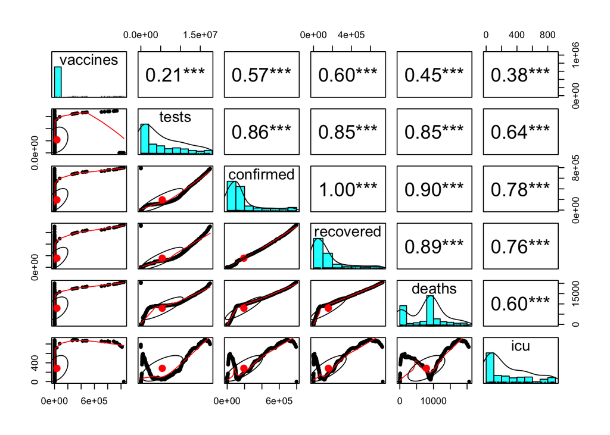

```r
pairs.panels(covid_data, stars = TRUE)
```

```r
data_mean = apply(covid_data, 2, mean)
data_mean
```

```
##    vaccines       tests   confirmed   recovered      deaths         icu
##   35540.451 5391749.436  192182.234  156747.648    7895.223     283.168
```

```r
data_var = apply(covid_data, 2, var)
data_var
```

```
##     vaccines        tests    confirmed    recovered       deaths          icu
## 2.750395e+10 2.775335e+13 4.566848e+10 3.536339e+10 3.031518e+07 7.462075e+04
```

Because the variables have different scales, we need to scale them to unit variance before finding the components.

```r
covid_data_pca = prcomp(covid_data, scale=TRUE)
summary(covid_data_pca)
```

```
## Importance of components:
##                           PC1    PC2     PC3    PC4    PC5     PC6
## Standard deviation     2.1342 0.9109 0.66880 0.3268 0.2461 0.02987
## Proportion of Variance 0.7591 0.1383 0.07455 0.0178 0.0101 0.00015
## Cumulative Proportion  0.7591 0.8974 0.97195 0.9898 0.9999 1.00000
```

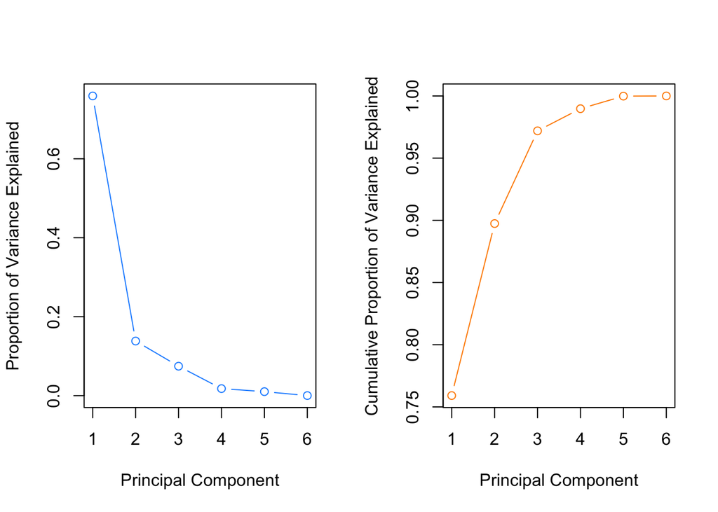

```r
pr.var = covid_data_pca$sdev ^ 2
pve = pr.var / sum(pr.var)
par(mfrow = c(1, 2))
plot(pve, xlab = " Principal Component ",
     ylab = " Proportion of Variance Explained ", type = 'b', col = "dodgerblue")
#The function cumsum() computes the cumulative sum of the elements of a numeric vector
plot(cumsum (pve), xlab = " Principal Component ",
     ylab = "Cumulative Proportion of Variance Explained", type = 'b',col = "darkorange")
```

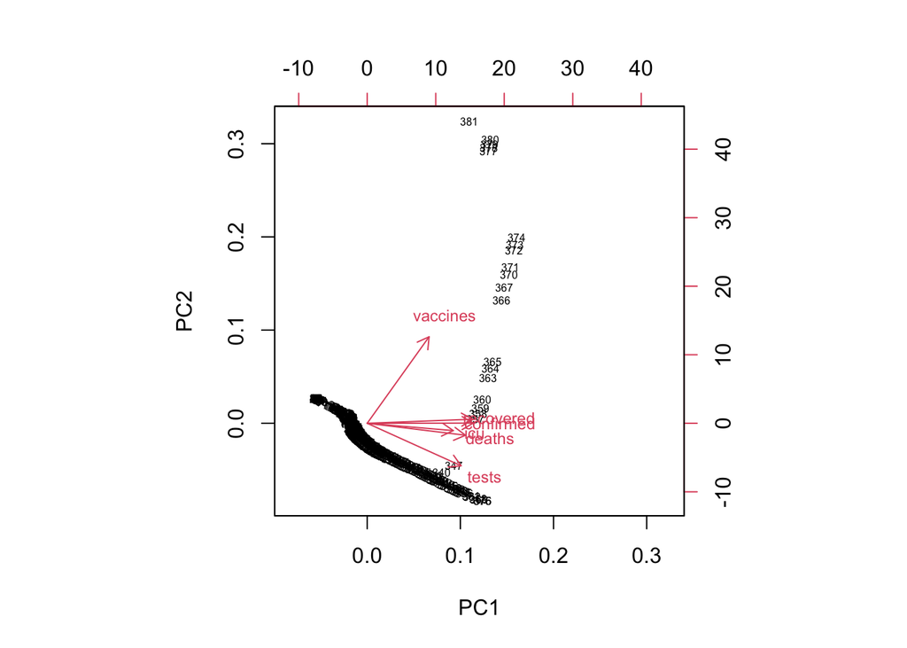

```r
biplot(covid_data_pca, cex = c(0.5, 0.75))
```

We notice that PC1 and PC2 explain together around 90% of the total variance. This means that nearly 90% of the information in the dataset can be determined by just the first two Principal Components.

Moreover from the proportional variance graph, we see that the elbow is located at the second PC which suggests the inclusion of PC1 and PC2 to represent the majority of the data.

```r
covid_data_pca$rotation
```

```
##                 PC1          PC2         PC3        PC4        PC5          PC6
## vaccines  0.2710262  0.887193758  0.08779743 -0.1423600 -0.3331348 -0.021873321
## tests     0.4113662 -0.436337516  0.21639534 -0.5575423 -0.5316645 -0.006320953
## confirmed 0.4649048  0.002058722  0.01162923 -0.1024765  0.4789873 -0.737423700
## recovered 0.4625930  0.041706581  0.06400647 -0.1906481  0.5416950  0.671112011
## deaths    0.4303403 -0.122911097  0.42160926  0.7628163 -0.1950362  0.044922044
## icu       0.3768304 -0.075139816 -0.87377241  0.2003583 -0.2131962  0.057258787
```

The second component is positively aligned with vaccines, (very weakly) confirmed, and (weakly) recovered, and negatively aligned with tests, deaths, and icu.

The second principal component (PC2) separates those who get the vaccine and recover and those who get tested, go to the icu and die. This suggests that people who receive the COVID-19 vaccine have a better chance at recovering. One interpretation of the negative grouping is that those who get tested do so because they believe that they might have COVID-19. Thus, if they do test positive, there is a (small) correlated chance that they end up in icu and succumb to illness or end up dying at home.